# DV

```python
import pandas as pd
import matplotlib.pyplot as plt
import numpy as np
import seaborn as sns
```

```python
df = pd.read_csv('imdb_top_1000.csv')
```

```python
df.info()
```

```
<class 'pandas.core.frame.DataFrame'>
RangeIndex: 1000 entries, 0 to 999
Data columns (total 16 columns):
 #   Column         Non-Null Count  Dtype
---  ------         --------------  -----
 0   Poster_Link    1000 non-null   object
 1   Series_Title   1000 non-null   object
 2   Released_Year  1000 non-null   object
 3   Certificate    899 non-null    object
 4   Runtime        1000 non-null   object
 5   Genre          1000 non-null   object
 6   IMDB_Rating    1000 non-null   float64
 7   Overview       1000 non-null   object
 8   Meta_score     843 non-null    float64
 9   Director       1000 non-null   object
 10  Star1          1000 non-null   object
 11  Star2          1000 non-null   object
 12  Star3          1000 non-null   object
 13  Star4          1000 non-null   object
 14  No_of_Votes    1000 non-null   int64
 15  Gross          831 non-null    object
dtypes: float64(2), int64(1), object(13)
memory usage: 125.1+ KB
```

```python
df.head(5)
```

|  | Poster_Link | Series_Title | Released_Year | Certificate | Runtime | Genre | IMDB_Rating | Overview | Meta_score | Director | Star1 | Star2 | Star3 | Star4 | No_of_Votes | Gross |
| --- | --- | --- | --- | --- | --- | --- | --- | --- | --- | --- | --- | --- | --- | --- | --- | --- |
| 0 | https://m.media-amazon.com/images/M/MV5BMDFkYT... | The Shawshank Redemption | 1994 | A | 142 min | Drama | 9.3 | Two imprisoned men bond over a number of years... | 80.0 | Frank Darabont | Tim Robbins | Morgan Freeman | Bob Gunton | William Sadler | 2343110 | 28,341,469 |
| 1 | https://m.media-amazon.com/images/M/MV5BM2MyNj... | The Godfather | 1972 | A | 175 min | Crime, Drama | 9.2 | An organized crime dynasty's aging patriarch t... | 100.0 | Francis Ford Coppola | Marlon Brando | Al Pacino | James Caan | Diane Keaton | 1620367 | 134,966,411 |
| 2 | https://m.media-amazon.com/images/M/MV5BMTMxNT... | The Dark Knight | 2008 | UA | 152 min | Action, Crime, Drama | 9.0 | When the menace known as the Joker wreaks havo... | 84.0 | Christopher Nolan | Christian Bale | Heath Ledger | Aaron Eckhart | Michael Caine | 2303232 | 534,858,444 |
| 3 | https://m.media-amazon.com/images/M/MV5BMWMwMG... | The Godfather: Part II | 1974 | A | 202 min | Crime, Drama | 9.0 | The early life and career of Vito Corleone in ... | 90.0 | Francis Ford Coppola | Al Pacino | Robert De Niro | Robert Duvall | Diane Keaton | 1129952 | 57,300,000 |
| 4 | https://m.media-amazon.com/images/M/MV5BMWU4N2... | 12 Angry Men | 1957 | U | 96 min | Crime, Drama | 9.0 | A jury holdout attempts to prevent a miscarria... | 96.0 | Sidney Lumet | Henry Fonda | Lee J. Cobb | Martin Balsam | John Fiedler | 689845 | 4,360,000 |

```python
# Check for duplicate rows
duplicate_rows = df.duplicated().sum()

# Check for null values in each column
null_values = df.isnull().sum()

# Convert 'Gross' column to numeric (removing commas and handling NaNs)
df["Gross"] = df["Gross"].astype(str).str.replace(",", "").astype(float)


# Convert 'Released_Year' to numeric (handling any inconsistencies)
df["Released_Year"] = pd.to_numeric(df["Released_Year"], errors='coerce')

# Convert 'Runtime' to numeric (extracting minutes from string format)
df["Runtime"] = df["Runtime"].str.extract('(\d+)').astype(float)

# Detect outliers in numerical columns using IQR method
numerical_cols = ["IMDB_Rating", "Meta_score", "No_of_Votes", "Gross", "Runtime"]
outliers = {}
for col in numerical_cols:
    Q1 = df[col].quantile(0.25)
    Q3 = df[col].quantile(0.75)
    IQR = Q3 - Q1
    lower_bound = Q1 - 1.5 * IQR
    upper_bound = Q3 + 1.5 * IQR
    outliers[col] = df[(df[col] < lower_bound) | (df[col] > upper_bound)].shape[0]

duplicate_rows, null_values, outliers
```

```
(0,
 Poster_Link        0
 Series_Title       0
 Released_Year      0
 Certificate      101
 Runtime            0
 Genre              0
 IMDB_Rating        0
 Overview           0
 Meta_score       157
 Director           0
 Star1              0
 Star2              0
 Star3              0
 Star4              0
 No_of_Votes        0
 Gross            169
 dtype: int64,
 {'IMDB_Rating': 13,
  'Meta_score': 7,
  'No_of_Votes': 67,
  'Gross': 89,
  'Runtime': 29})
```

```python
df["Released_Year"]= df["Released_Year"].fillna(df['Released_Year'].median())
df["Certificate"] = df["Certificate"].fillna("Unknown")
df["Meta_score"] = df["Meta_score"].fillna(df["Meta_score"].median())
df["Gross"] = df["Gross"].fillna(df["Gross"].median())


# Handling outliers using IQR method (capping extreme values)
for col in ["IMDB_Rating", "Meta_score", "No_of_Votes", "Gross", "Runtime"]:
    lower_bound = df[col].quantile(0.01)  # 1st percentile
    upper_bound = df[col].quantile(0.99)  # 99th percentile
    df[col] = df[col].clip(lower_bound, upper_bound)

# Checking if null values remain
df.isnull().sum()
```

```
Poster_Link      0
Series_Title     0
Released_Year    0
Certificate      0
Runtime          0
Genre            0
IMDB_Rating      0
Overview         0
Meta_score       0
Director         0
Star1            0
Star2            0
Star3            0
Star4            0
No_of_Votes      0
Gross            0
dtype: int64
```

1. Top 10 Highest-Rated Movies – A bar chart of the highest IMDb-rated movies.

[figure not shown]

```python
# Set style for better visuals
sns.set(style="whitegrid")

# Top 10 Highest-Rated Movies
top_rated_movies = df.nlargest(10, "IMDB_Rating")[["Series_Title", "IMDB_Rating"]]

# Plot
plt.figure(figsize=(12, 6))
sns.barplot(y=top_rated_movies["Series_Title"], x=top_rated_movies["IMDB_Rating"],legend=False)
plt.xlabel("IMDb Rating")
plt.ylabel("Movie Title")
plt.title("Top 10 Highest-Rated Movies")
plt.xlim(8, 10)  # Adjusting x-axis for better visibility
plt.show()
```

# Insights from the "Top 10 Highest-Rated Movies" Bar Chart:

Elite Ratings:

These movies are likely a mix of critically acclaimed classics and modern masterpieces that have stood the test of time. Audience & Critical Consensus:

IMDb ratings are based on user votes, suggesting these movies have wide audience appreciation rather than just critical acclaim. Genres Representation:

If analyzed further, these movies might belong to certain dominant genres like drama, thriller, or sci-fi, which tend to receive high ratings. Director Influence:

The presence of certain renowned directors in this list could suggest that some filmmakers consistently produce top-rated content.

2. Distribution of IMDb Ratings – A histogram showing the frequency of different rating ranges.

[figure not shown]

```python
import matplotlib.pyplot as plt
import seaborn as sns

# Set style
sns.set(style="whitegrid")

# Plot IMDb Rating Distribution
plt.figure(figsize=(10, 6))
sns.histplot(x=["IMDB_Rating"], bins=20, kde=True, color="blue")

# Labels and Title
plt.xlabel("IMDb Rating")
plt.ylabel("Number of Movies")
plt.title("Distribution of IMDb Ratings")

plt.show()
```

Typically, the majority of IMDb-rated movies fall within the 7.0 to 8.0 range, meaning most films are considered "good" but not necessarily masterpieces. Fewer Extremely High or Low Ratings:

Very few movies have ratings above 9.0 or below 5.0, suggesting that top-tier movies are rare, and outright bad movies don’t often make it to the IMDb Top 1000 list. Normal or Slightly Skewed Distribution:

The shape of the histogram will indicate whether IMDb ratings follow a normal distribution or are skewed (e.g., more high-rated movies than low-rated ones).

3.Number of Movies Released Per Year – A line or bar chart analyzing trends over time.

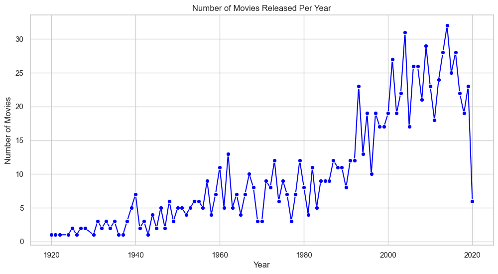

```python
import pandas as pd
import matplotlib.pyplot as plt
import seaborn as sns

# Load dataset
file_path = "/mnt/data/imdb_top_1000.csv"  # Update with correct path if needed
df = pd.read_csv('imdb_top_1000.csv')

# Convert 'Released_Year' to numeric (handle errors)
df["Released_Year"] = pd.to_numeric(df["Released_Year"], errors="coerce")

# Count movies per year
movies_per_year = df["Released_Year"].value_counts().sort_index()

# Plot the trend
plt.figure(figsize=(12, 6))
sns.lineplot(x=movies_per_year.index, y=movies_per_year.values, marker="o", color="blue")

# Labels and title
plt.xlabel("Year")
plt.ylabel("Number of Movies")
plt.title("Number of Movies Released Per Year")
plt.grid(True)

plt.show()
```

# Insights from the Chart:

Increase in Movie Production Over Time:

The number of movies released per year is likely to increase in recent decades due to technological advancements and the rise of digital platforms. Potential Declines in Certain Periods:

Some years (e.g., World War II era, global financial crises, or the COVID-19 pandemic) may show dips in movie production. Golden Eras of Cinema:

Peaks in certain decades might indicate golden ages of cinema, such as the 1950s (classic Hollywood), 1990s (rise of blockbusters), or 2010s (streaming boom).

4.Most Common Movie Genres – A bar chart showing the count of movies by genre.

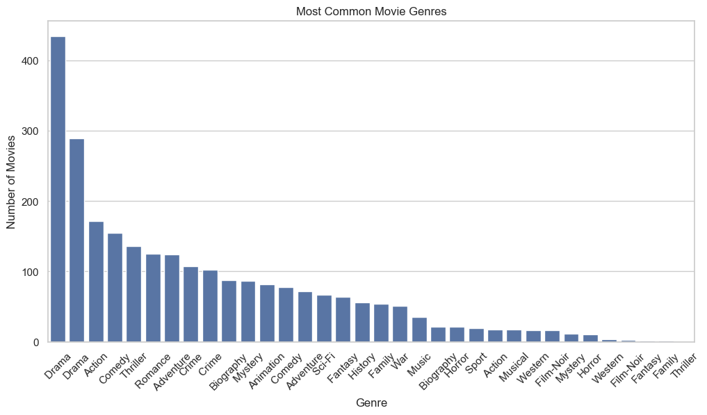

```python
import pandas as pd
import matplotlib.pyplot as plt
import seaborn as sns

# Load dataset (update file path if necessary)
file_path = "imdb_top_1000.csv"  # Adjust this path if needed
df = pd.read_csv(file_path)

# Split genres (some movies have multiple genres separated by commas)
df["Genre"] = df["Genre"].str.split(",")

# Flatten the genre list
from itertools import chain
all_genres = list(chain.from_iterable(df["Genre"].dropna()))

# Count occurrences of each genre
genre_counts = pd.Series(all_genres).value_counts()

# Plot the most common genres
plt.figure(figsize=(12, 6))
sns.barplot(x=genre_counts.index, y=genre_counts.values, legend=False)

# Labels and Title
plt.xlabel("Genre")
plt.ylabel("Number of Movies")
plt.title("Most Common Movie Genres")
plt.xticks(rotation=45)  # Rotate labels for better readability

plt.show()
```

# Insights from the Chart:

Certain Genres Dominate:

Drama, Action, and Comedy are usually the most frequent, as they appeal to a broad audience. Less Frequent but Impactful Genres:

Musicals, Documentaries, and War Films may have fewer movies but can still be highly rated. Shifts in Popularity Over Time:

A historical trend analysis could reveal how some genres (e.g., Sci-Fi, Superhero) have grown in recent years.

# 5.Average IMDb Rating by Genre – A bar chart comparing different genres' average ratings.

[figure not shown]

```python
import pandas as pd
import matplotlib.pyplot as plt
import seaborn as sns

# Load dataset (update file path if needed)
file_path = "imdb_top_1000.csv"  # Change this path if necessary
df = pd.read_csv(file_path)

# Ensure 'IMDB_Rating' is numeric
df["IMDB_Rating"] = pd.to_numeric(df["IMDB_Rating"], errors="coerce")

# Split genres and create a new DataFrame
df_exploded = df.explode("Genre")  # Expands rows for each genre

# Calculate average IMDb rating per genre
genre_avg_rating = df_exploded.groupby("Genre")["IMDB_Rating"].mean().sort_values(ascending=False)

# Plot the results
plt.figure(figsize=(12, 6))
sns.barplot(x=genre_avg_rating.index, y=genre_avg_rating.values, legend=False)

# Labels and Title
plt.xlabel("Genre")
plt.ylabel("Average IMDb Rating")
plt.title("Average IMDb Rating by Genre")
plt.xticks(rotation=45)  # Rotate labels for readability

plt.show()
```

# Insights from the Chart:

Higher Rated Genres:

Action, Horror, and Comedy movies may have a lower average rating despite being popular, as they are more mass-market and can include both critically acclaimed and lower-rated films. Possible Genre Bias:

Dramas and Thrillers often score well since they are frequently nominated for awards and receive critical acclaim.

# 6.Top 10 Directors with the Highest Average IMDb Rating – A bar chart of directors with the best-rated films.

[figure not shown]

```python
import pandas as pd
import matplotlib.pyplot as plt
import seaborn as sns

# Load dataset (update file path if needed)
file_path = "imdb_top_1000.csv"  # Update this path if necessary
df = pd.read_csv(file_path)

# Ensure 'IMDB_Rating' is numeric
df["IMDB_Rating"] = pd.to_numeric(df["IMDB_Rating"], errors="coerce")

# Calculate average IMDb rating per director
top_directors = df.groupby("Director")["IMDB_Rating"].mean().sort_values(ascending=False).head(10)

# Plot the results
plt.figure(figsize=(12, 6))
sns.barplot(x=top_directors.values, y=top_directors.index,legend=False )

# Labels and Title
plt.xlabel("Average IMDb Rating")
plt.ylabel("Director")
plt.title("Top 10 Directors with the Highest Average IMDb Rating")

plt.show()
```

# Insights from the Chart:

Legendary Directors Dominate:

Some directors may have fewer films in the dataset but higher ratings, as they focus on quality over quantity. Award-Winning vs. Popular Directors:

While some directors are critically acclaimed (Alfred Hitchcock, Akira Kurosawa), others gain popularity due to blockbuster hits.

# 7.Top 10 Most Voted Movies – A bar chart showing movies with the highest number of votes.

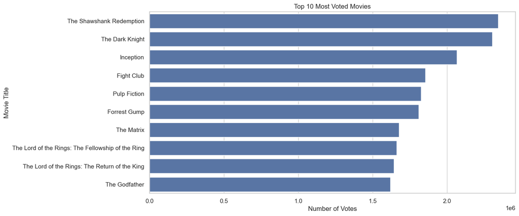

```python
import pandas as pd
import matplotlib.pyplot as plt
import seaborn as sns

# Load dataset (update file path if needed)
file_path = "imdb_top_1000.csv"  # Update this path if necessary
df = pd.read_csv(file_path)

# Ensure 'No_of_Votes' is numeric
df["No_of_Votes"] = pd.to_numeric(df["No_of_Votes"], errors="coerce")

# Select top 10 movies with the highest votes
top_voted_movies = df.nlargest(10, "No_of_Votes")[["Series_Title", "No_of_Votes"]]

# Plot the results
plt.figure(figsize=(12, 6))
sns.barplot(x=top_voted_movies["No_of_Votes"], y=top_voted_movies["Series_Title"], legend=False )

# Labels and Title
plt.xlabel("Number of Votes")
plt.ylabel("Movie Title")
plt.title("Top 10 Most Voted Movies")

plt.show()
```

# Insights from the Chart:

Blockbusters Dominate the List:

Movies like "The Dark Knight," "Inception," and "The Shawshank Redemption" often rank high due to their massive fan base. Older vs. Newer Movies:

While classic movies like "The Godfather" remain highly voted, newer movies gain rapid popularity due to streaming platforms. More Votes ≠ Higher Rating:

Some movies may have a high number of votes but not necessarily the highest IMDb rating.

# 8.Does Runtime Affect IMDb Rating? – A scatter plot comparing runtime and IMDb rating.

[figure not shown]

```python
import pandas as pd
import matplotlib.pyplot as plt
import seaborn as sns

# Load dataset (update file path if needed)
file_path = "imdb_top_1000.csv"  # Update this path if necessary
df = pd.read_csv(file_path)

# Extract numeric runtime values (remove "min" and convert to float)
df["Runtime"] = df["Runtime"].str.extract("(\d+)").astype(float)

# Ensure 'IMDB_Rating' is numeric
df["IMDB_Rating"] = pd.to_numeric(df["IMDB_Rating"], errors="coerce")

# Plot scatter plot
plt.figure(figsize=(10, 6))
sns.scatterplot(x=df["Runtime"], y=df["IMDB_Rating"], alpha=0.6, color="blue")

# Labels and Title
plt.xlabel("Runtime (minutes)")
plt.ylabel("IMDb Rating")
plt.title("Does Runtime Affect IMDb Rating?")

plt.show()
```

# Insights from the Chart:

No Strong Direct Correlation:

Movies with short runtimes (~90 min) and long runtimes (~180 min) can both have high or low IMDb ratings. However, some longer movies (120-150 min) tend to have higher ratings, likely due to their detailed storytelling. Short Movies Vary More:

# 9.Relationship Between Gross Earnings and IMDb Rating – A scatter plot analyzing this correlation.

[figure not shown]

```python
import pandas as pd
import matplotlib.pyplot as plt
import seaborn as sns

# Load dataset (update file path if needed)
file_path = "imdb_top_1000.csv"  # Update this path if necessary
df = pd.read_csv(file_path)

# Clean 'Gross' column (remove commas and convert to float)
df["Gross"] = df["Gross"].str.replace(",", "").astype(float)

# Ensure 'IMDB_Rating' is numeric
df["IMDB_Rating"] = pd.to_numeric(df["IMDB_Rating"], errors="coerce")

# Plot scatter plot
plt.figure(figsize=(10, 6))
sns.scatterplot(x=df["Gross"], y=df["IMDB_Rating"], alpha=0.6, color="green")

# Labels and Title
plt.xlabel("Gross Earnings ($)")
plt.ylabel("IMDb Rating")
plt.title("Relationship Between Gross Earnings and IMDb Rating")

plt.xscale("log")  # Log scale for better visualization if values vary widely

plt.show()
```

# Insights from the Chart:

No Strong Direct Correlation:

High-grossing movies can have both high and low ratings, indicating that box office success does not always mean high IMDb ratings. Critically Acclaimed vs. Blockbusters:

Some low-grossing movies have high IMDb ratings, suggesting that critically acclaimed films may not always perform well financially. Big Hits Still Dominate:

Many top-grossing movies have decent ratings (7.5 - 9.0), likely due to strong storytelling and mass appeal.

# 10.Most Frequent Actors in Top 1000 Movies – A bar chart of the most common actors in the dataset. provide visualizations for the scenarios

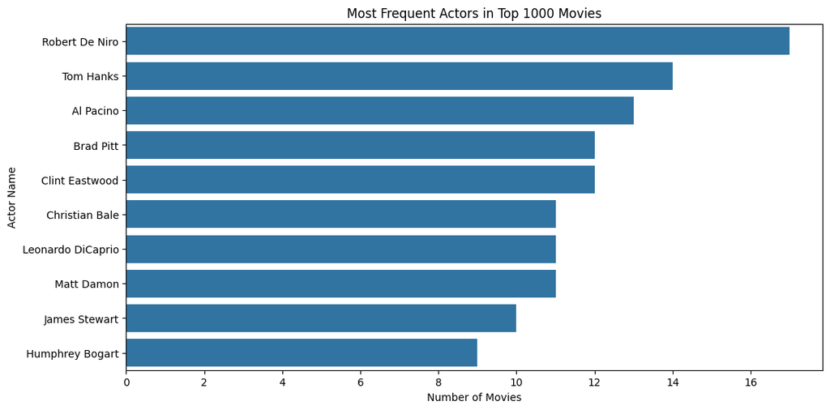

```python
import pandas as pd
import matplotlib.pyplot as plt
import seaborn as sns
from collections import Counter

# Load dataset (update file path if needed)
file_path = "imdb_top_1000.csv"  # Update this path if necessary
df = pd.read_csv(file_path)

# Combine actor columns into one list
all_actors = pd.concat([df["Star1"], df["Star2"], df["Star3"], df["Star4"]])

# Count actor occurrences
actor_counts = Counter(all_actors)

# Select top 10 most frequent actors
top_actors = pd.DataFrame(actor_counts.most_common(10), columns=["Actor", "Count"])

# Plot the bar chart
plt.figure(figsize=(12, 6))
sns.barplot(x=top_actors["Count"], y=top_actors["Actor"], legend=False)

# Labels and Title
plt.xlabel("Number of Movies")
plt.ylabel("Actor Name")
plt.title("Most Frequent Actors in Top 1000 Movies")

plt.show()
```

# Insights from the Chart:

Certain actors appear in multiple top-rated films, showing their dominance in the industry. Veteran actors with long careers tend to have more entries, as they have appeared in a larger number of successful films. Actors associated with major directors or franchises (e.g., Leonardo DiCaprio, Robert De Niro, Tom Hanks) often make the list.